# Python Crash Course

```python
print('Hello Python World')
```

```
Hello Python World
```

```python
message = 'Hello Python World'
print(message)
```

```
Hello Python World
```

```python
# Creating an error on purpose
#print(mesage)
```

### Try it yourself

```python
simple_msg = 'This is a simple message.'
print(simple_msg)
```

```
This is a simple message.
```

### Strings

```python
# The flexibility of strings allows you to use quotes and apostrophes within your strings
print('I told my friend, "Python is named after Monty Python, not the snake." ')
```

```
I told my friend, "Python is named after Monty Python, not the snake."
```

```python
# Changing the case of the word
name = 'lena paul'
print(name.title())
```

```
Lena Paul
```

In the previous chunk, we used a method title(). A method is an action that python can perform on a piece of data. Every method is followed by a parentheses because methods often need additional information which is provided inside the parentheses. The method title() does not need more information to do its work.

```python
# Changing a string to all uppercase or lowercase.
print(name.upper())
print(name.lower() == name)

# store your data in lowercase.
#Use the case that makes the most sense for each string when displaying information

print("Hello {}!".format(name.title()))
```

```
LENA PAUL
True
Hello Lena Paul!
```

```python
# Stripping whitespace
language = 'python '
display(language)
display(language.rstrip())
```

```
'python '
```

```
'python'
```

```python
# Using apostrophes properly within strings - use double quotes
print("One of Python's strengths is its diverse community.")
```

```
One of Python's strengths is its diverse community.
```

### Try it Yourself - Strings

```python
# Personal Message
name2 = 'eric'
language = 'python'
print('Hello {}, would you like to learn some {} today?'.format(name2, language))

print('\n')
print('Name Cases:')
print('Hello {}, would you like to learn some {} today?'.format(name2.title(), language.title()))

print('\n')
print('Famous Quote:')
print('Michael Scott once said "You miss 100% of the shots you do not take. - Wayne Gretzky" ')

print('\nAdding WhiteSpace:')
print('\tPython\n\tR')
```

```
Hello eric, would you like to learn some python today?


Name Cases:
Hello Eric, would you like to learn some Python today?


Famous Quote:
Michael Scott once said "You miss 100% of the shots you do not take. - Wayne Gretzky"

Adding WhiteSpace:
	Python
	R
```

## Lists

```python
bicycles = ['trek', 'cannondale', 'redline', 'specialized']
print(bicycles)
```

```
['trek', 'cannondale', 'redline', 'specialized']
```

```python
# Accessing elements in a list
print(bicycles[0].title())
print(bicycles[1].title())
print(bicycles[-1].title()) # the last element in the list
```

```
Trek
Cannondale
Specialized
```

```python
print('My first bicyle was a {}'.format(bicycles[1]))
```

```
My first bicyle was a cannondale
```

### Changing, Adding, and Removing Elements

```python
motorcycles = ['honda', 'yamaha', 'suzuki']
motorcycles[0] = 'ducati'
print(motorcycles)

# Appending elements - adding them to the end of the list
motorcycles.append('honda')
print(motorcycles)

# Using the insert method will shift every other value in the list one position to the right.
motorcycles = ['honda', 'yamaha', 'suzuki']
motorcycles.insert(0, 'ducati')
print(motorcycles)
```

```
['ducati', 'yamaha', 'suzuki']
['ducati', 'yamaha', 'suzuki', 'honda']
['ducati', 'honda', 'yamaha', 'suzuki']
```

#### Removing Elements

```python
motorcycles = ['honda', 'yamaha', 'suzuki']
del motorcycles[0] # you can remove an item from any position
print(motorcycles)
```

```
['yamaha', 'suzuki']
```

###### Sometimes, we will want to use the value of an item after we remove it from the list

###### The pop method allows you to remove the last item in a list but lets you work with that item after removing it.

```python
motorcycles = ['honda', 'yamaha', 'suzuki']
motorcycles_popped = motorcycles.pop()
print(motorcycles)
print(motorcycles_popped)

## You can also pop an item at any position from the list.
motorcycles = ['honda', 'yamaha', 'suzuki']
print('My second bike was a {}'.format(motorcycles.pop(1)))
```

```
['honda', 'yamaha']
suzuki
My second bike was a yamaha
```

###### The best way to remove an element from a list, becaus you might not know the position of that element, is to use the remove method. However, it will only remove the first occurrence of the value you specify. Use a loop to remove all occurrences.

```python
motorcycles = ['honda', 'yamaha', 'suzuki']
motorcycles.remove('honda')
print(motorcycles)
```

```
['yamaha', 'suzuki']
```

### Try it Yourself

```python
dinner_list = ['Eric Eager', 'George Chahrouri', 'John Urschel']

print('Hello {}. I am having a dinner party and would appreciate it if you attend. Your Biggest Fan!'.format(dinner_list[0]))
print('Hello {}. I am having a dinner party and would appreciate it if you attend. Your Biggest Fan!'.format(dinner_list[1]))
print('Hello {}. I am having a dinner party and would appreciate it if you attend. Your Biggest Fan!'.format(dinner_list[2]))
```

```
Hello Eric Eager. I am having a dinner party and would appreciate it if you attend. Your Biggest Fan!
Hello George Chahrouri. I am having a dinner party and would appreciate it if you attend. Your Biggest Fan!
Hello John Urschel. I am having a dinner party and would appreciate it if you attend. Your Biggest Fan!
```

```python
dinner_list = ['Eric Eager', 'George Chahrouri', 'John Urschel']
print("Just hear from {}. He cannot make it to the party.".format(dinner_list[2]))
dinner_list[2] = 'caio brighenti'.title()

print('\n')
for i in dinner_list:
    print('Hello {}. I am having a dinner party and would appreciate it if you attend. Your Biggest Fan!'.format(i))
```

```
Just hear from John Urschel. He cannot make it to the party.


Hello Eric Eager. I am having a dinner party and would appreciate it if you attend. Your Biggest Fan!
Hello George Chahrouri. I am having a dinner party and would appreciate it if you attend. Your Biggest Fan!
Hello Caio Brighenti. I am having a dinner party and would appreciate it if you attend. Your Biggest Fan!
```

```python
## Inviting more guests
dinner_list = ['Eric Eager', 'George Chahrouri', 'caio brighenti'.title()]
dinner_list.insert(0, 'Howie Roseman')
dinner_list.insert(2, 'john harbaugh'.title())
dinner_list.append('greg cosell'.title())

# Printing the new invitations
for i in dinner_list:
    print('Hello {}. I am having a dinner party and would appreciate it if you attend. Your Biggest Fan!'.format(i))
```

```
Hello Howie Roseman. I am having a dinner party and would appreciate it if you attend. Your Biggest Fan!
Hello Eric Eager. I am having a dinner party and would appreciate it if you attend. Your Biggest Fan!
Hello John Harbaugh. I am having a dinner party and would appreciate it if you attend. Your Biggest Fan!
Hello George Chahrouri. I am having a dinner party and would appreciate it if you attend. Your Biggest Fan!
Hello Caio Brighenti. I am having a dinner party and would appreciate it if you attend. Your Biggest Fan!
Hello Greg Cosell. I am having a dinner party and would appreciate it if you attend. Your Biggest Fan!
```

```python
## Shrinking the guest list
print('Unfortunately, you can invite only two people for dinner. Here is the list you should modify {}'.format(dinner_list))
i = [1,3,4]

print('\n')
for position in i:
    print('Sorry {}, there is not room at the table'.format(dinner_list[position]))

print('\nPeople that still invited')
invited = [0,2]
for position in invited:
    print('{}, you are still invited to dinner. See you then!'.format(dinner_list[position] ))
```

```
Unfortunately, you can invite only two people for dinner. Here is the list you should modify ['Howie Roseman', 'Eric Eager', 'John Harbaugh', 'George Chahrouri', 'Caio Brighenti', 'Greg Cosell']


Sorry Eric Eager, there is not room at the table
Sorry George Chahrouri, there is not room at the table
Sorry Caio Brighenti, there is not room at the table

People that still invited
Howie Roseman, you are still invited to dinner. See you then!
John Harbaugh, you are still invited to dinner. See you then!
```

### Organizing a List

```python
cars = ['bmw', 'audi', 'toyota', 'subaru']
cars.sort() # Changes the order of the list permanently.
print(cars)
cars.sort(reverse = True) # Descending order
print(cars)
```

```
['audi', 'bmw', 'subaru', 'toyota']
['toyota', 'subaru', 'bmw', 'audi']
```

#### To sort a list temporarily, use the sorted function

```python
cars = ['bmw', 'audi', 'toyota', 'subaru']
print('Here is the original list: \n{}'.format(cars))

print('\nHere is the list sorted backwards alphabetically: \n{}'.format(sorted(cars, reverse = True)))
print('\nNotice that the original list did not change: \n{}'.format(cars))
```

```
Here is the original list:
['bmw', 'audi', 'toyota', 'subaru']

Here is the list sorted backwards alphabetically:
['toyota', 'subaru', 'bmw', 'audi']

Notice that the original list did not change:
['bmw', 'audi', 'toyota', 'subaru']
```

```python
# Reversing the order of the list.
# This is not the same thing as sorting in descending order or sorting backwars alphabetically
cars = ['bmw', 'audi', 'toyota', 'subaru']
cars.reverse()
print(cars) # A permanent operation
```

```
['subaru', 'toyota', 'audi', 'bmw']
```

### Try it Yourself - Seeing the World

```python
places = ['New Zealand', 'Norway', 'Germany', 'England', 'New York City']
print(places)

print('\nHere is the sorted list: \n{}'.format(sorted(places)))
print('\nThe original order of the list is preserved: \n{}'.format(places))
print('\nHere is the sorted list in reverse alphabetical order: \n{}'.format(sorted(places, reverse = True)))
print('\nBut, original order of the list is preserved: \n{}'.format(places))

places.reverse()
print('\nI permanently reversed the order of your list: \n{}'.format(places))
places.reverse()
print('\nFine, I will change it back: \n{}'.format(places))
```

```
['New Zealand', 'Norway', 'Germany', 'England', 'New York City']

Here is the sorted list:
['England', 'Germany', 'New York City', 'New Zealand', 'Norway']

The original order of the list is preserved:
['New Zealand', 'Norway', 'Germany', 'England', 'New York City']

Here is the sorted list in reverse alphabetical order:
['Norway', 'New Zealand', 'New York City', 'Germany', 'England']

But, original order of the list is preserved:
['New Zealand', 'Norway', 'Germany', 'England', 'New York City']

I permanently reversed the order of your list:
['New York City', 'England', 'Germany', 'Norway', 'New Zealand']

Fine, I will change it back:
['New Zealand', 'Norway', 'Germany', 'England', 'New York City']
```

### Dinner Guests

```python
print('You have invited {} people to dinner'.format(len(dinner_list)))
```

```
You have invited 6 people to dinner
```

### Working with Lists

Helpful to do things like displaying each headline from a list of articles on a website, or performing the same statistical operation on every number in a list

```python
magicians = ['alice', 'david', 'carolina']
for people in magicians:
    print("Thank you {}, for an excellent show. We can't wait to see you next time!".format(people.title()))
```

```
Thank you Alice, for an excellent show. We can't wait to see you next time!
Thank you David, for an excellent show. We can't wait to see you next time!
Thank you Carolina, for an excellent show. We can't wait to see you next time!
```

### Try it yourself - Loops and Lists

```python
pizzas = ['New York Pizza', 'Deep Dish Pizza', 'Greek Pizza']
for pizza in pizzas:
    print('I like {}'.format(pizza))
```

```
I like New York Pizza
I like Deep Dish Pizza
I like Greek Pizza
```

### Making Numerical Lists

Many reasons exist for using numerical lists, such as keeping track of positions of each character in a game, or keeping track of a player's high score

##### Using the range function

Remember that the range function also follows the off-by-one behaviour. It will start counting at the first value, and will never print the end value

```python
numbers = list(range(1,6))
print(numbers)
```

```
[1, 2, 3, 4, 5]
```

```python
even_numbers = list(range(2,10,2))
print(even_numbers)

squared_numbers = []
for i in range(1,11):
    squared_numbers.append(i**2)
print('\nHere is the list of squared numbers: \n{}'.format(squared_numbers))

print("\nLet's do simple statistics with a list of numbers:")
digits = list(range(1,10))
digits.append(0)
print(digits)
print(min(digits))
print(max(digits))
print(sum(digits))
```

```
[2, 4, 6, 8]

Here is the list of squared numbers:
[1, 4, 9, 16, 25, 36, 49, 64, 81, 100]

Let's do simple statistics with a list of numbers:
[1, 2, 3, 4, 5, 6, 7, 8, 9, 0]
0
9
45
```

### List Comprehensions

Generating a list using one line of code by combining a for loop and the creation of new elements into one line.

```python
squares = [i**2 for i in range(1,11)]
print(squares)
```

```
[1, 4, 9, 16, 25, 36, 49, 64, 81, 100]
```

### Try it yourself

```python
### Counting to twenty
for i in range(0,21):
    print(i)

print('\n')
### Odd numbers
for i in range(1,20,2):
    print(i)

print('\n')
### Using Cubes Comprehension
cubes = [value**3 for value in range(1,11)]
print(cubes)
```

```
0
1
2
3
4
5
6
7
8
9
10
11
12
13
14
15
16
17
18
19
20


1
3
5
7
9
11
13
15
17
19


[1, 8, 27, 64, 125, 216, 343, 512, 729, 1000]
```

## Tuples

Sometimes, you want to create a list of items that do not change. Thus, a tuple is an immutable list.

```python
# Say you have a rectangle and do not want to change its dimensions
dimensions = (200,50)
print(dimensions[0])
print(dimensions[1])

#dimensions[0] = 100 Will raise a type error.
```

```
200
50
```

```python
# In order to modify your tuple, you can redefine the entire tuple
dimensions = (200,50)
print('Original dimensions are {}'.format(dimensions))
dimensions = (400,100)
print('\nModified dimensions are {}'.format(dimensions))
```

```
Original dimensions are (200, 50)

Modified dimensions are (400, 100)
```

#### Try it yourself - Buffet

```python
food = ('sandwich', 'burger', 'ice tea', 'coffee', 'fries')

for i in food:
    print(i.title())

print('\nThe old menu has been updated to:')
food = ('sandwich', 'burger', 'ice tea', 'pancakes', 'soda')
for i in food:
    print(i.title())
```

```
Sandwich
Burger
Ice Tea
Coffee
Fries

The old menu has been updated to:
Sandwich
Burger
Ice Tea
Pancakes
Soda
```

## If Statements

Allows you to examine the current state of your program and respond appropriately to that state. For instance, you can use if statements and a for loop on a list to handle some items in that list one way, but handle items with specific values a different way.

```python
cars = ['audi', 'bmw', 'subaru', 'toyota']

for car in cars:
    if car == 'bmw':
        print(car.upper())
    else:
        print(car.title())
```

```
Audi
BMW
Subaru
Toyota
```

```python
## Checking Multiple Conditions
age_0 = 22
age_1 = 18

(age_0 >= 21) and (age_1 >= 21) # don't have to use parentheses.
```

```
False
```

```python
# Checking whether a particular value is in a list
requested_toppings = ['mushrooms', 'onions', 'black olives']
print('mushrooms' in requested_toppings)

banned_users = ['andrew', 'carolina', 'david']
if 'marie' not in banned_users:
    print('\n{}, you can pose a response if you wish'.format('marie'.title()))
```

```
True

Marie, you can pose a response if you wish
```

```python
## Using if-elif-else statement - As soon as python finds the test that passes, it skips te rest of the tests
age = 12
if age < 4:
    price = 0
elif age < 18:
    price = 25
else:
    price = 40

print('Your admission costs is ${}'.format(price))
```

```
Your admission costs is $25
```

As soon as python finds the test that passes, it skips te rest of the tests. If you want to check all of the conditions of interest, or when more than one condition can be true, you should use a series of simple if statements with no elif or else blocks.

```python
requested_toppings = ['mushrooms','extra cheese']

if 'mushrooms' in requested_toppings:
    print('Adding Mushrooms')

if 'extra cheese' in requested_toppings:
    print('Adding Extra Cheese')

if 'olives' in requested_toppings:
    print('Adding Olives')

## Although a for loop that prints item in the list is concise, this code shows the difference between using multiple
## if statements rather than a if-elif-else statement. Each condition of an if statement is checked regardless of the
## results from the previous test.
```

```
Adding Mushrooms
Adding Extra Cheese
```

### Try it yourself - Alien Colors # 1

```python
alien_color = 'red'
if alien_color == 'green':
    print('You earned 5 points!!')
if alien_color == 'red':
    print('You earned 3 points!!')
```

```
You earned 3 points!!
```

```python
## Alien colors 2
alien_color = 'red'
if alien_color == 'green':
    print('You earned 5 points!!!')
else:
    print('You earned 10 points')
```

```
You earned 10 points
```

```python
# Stages of life
age = 20
if age < 2:
    print('You are a baby')
elif age < 4:
    print('You are a toddler')
elif age < 13:
    print('You are a kid')
elif age < 20:
    print('You are a teenager')
elif age < 65:
    print('You are an adult')
else:
    print('You are an elder')
```

```
You are an adult
```

```python
# Favorite Fruit
fav_fruits = ['Tangerines', 'Mango', 'Dried']
if 'oranges'.title() in fav_fruits:
    print('You really like Oranges')
if 'tangerines'.title() in fav_fruits:
    print('You really like Tangerines')
```

```
You really like Tangerines
```

## Using If Statements with Lists

```python
requested_toppings = ['mushrooms', 'green peppers', 'extra cheese']
for topping in requested_toppings:
    if topping == 'green peppers':
        print('Sorry, we are out {}'.format(topping.title()))
    else:
        print('Adding {}'.format(topping.title()))
```

```
Adding Mushrooms
Sorry, we are out Green Peppers
Adding Extra Cheese
```

```python
# Checking that a list is not empty, and printing the appropriate message
requested_toppings = []

if requested_toppings: # Python will return True if the list contains at least one item. An empty list evaluates to False
    for topping in requested_toppings:
        if topping == 'green peppers':
            print('Sorry, we are out {}'.format(topping.title()))

        else:
            print('Adding {}'.format(topping.title()))
else:
    print('Are you sure you want a plain pizza?')
```

```
Are you sure you want a plain pizza?
```

```python
# Using Multiple Lists - Sometimes, people make unusual requests
available_toppings = ['mushrooms', 'olives', 'green peppers', 'pepperoni', 'chilli peppers', 'extra cheese']
requested_toppings = ['mushrooms', 'french fries', 'extra cheese']

for topping in requested_toppings:
    if topping in available_toppings:
        print('Adding {}'.format(topping.title()))

    else:
        print("Sorry, we cannot add {}".format(topping.title()))
```

```
Adding Mushrooms
Sorry, we cannot add French Fries
Adding Extra Cheese
```

### Try it Yourself

```python
# Hello Admin
usernames = ['admin', 'jaden', 'tom', 'patrick', 'chris']

for name in usernames:
    if name == 'admin'.lower():
        print('Hello Admin, would you like to see a status report?')
    else:
        print('Hello {}, thanks for logging in again.'.format(name.title()))

# No users
print('\n')
usernames = []

if usernames:
    for name in usernames:
        if name == 'admin'.lower():
            print('Hello Admin, would you like to see a status report?')

        else:
            print('Hello {}, thanks for logging in again.'.format(name.title()))
else:
    print('We need to find some users')
```

```
Hello Admin, would you like to see a status report?
Hello Jaden, thanks for logging in again.
Hello Tom, thanks for logging in again.
Hello Patrick, thanks for logging in again.
Hello Chris, thanks for logging in again.


We need to find some users
```

```python
# Checking Usernames Excerice

# Lists
current_users = ['eric', 'willie', 'admin', 'erin', 'Ever']
new_users = ['sarah', 'Willie', 'PHIL', 'ever', 'Iona']

# Creating a copy of current usernames containing all lowercase versions
current_users_lower = [user.lower() for user in current_users]

# Making case insensitive comparisions between new_users and current_users_lower
for name in new_users:
    if name.lower() in current_users_lower:
        print('Username {} already taken. Please enter a new username'.format(name))
    else:
        print('Username {} already available'.format(name))
```

```
Username sarah already available
Username Willie already taken. Please enter a new username
Username PHIL already available
Username ever already taken. Please enter a new username
Username Iona already available
```

```python
# Ordinal Numbers Excercise
num = list(range(1,10))
for i in num:
    if i == 1:
        print('1st')
    elif i == 2:
        print('2nd')
    elif i == 3:
        print('3rd')
    else:
        print('{}th'.format(i))
```

```
1st
2nd
3rd
4th
5th
6th
7th
8th
9th
```

## Dictionaries

```python
# Consider a game featuring aliens that can have different colors and point values.
alien_o = {'color': 'green', 'points': 5}
print(alien_o['color'])
print('You earned {} points'.format(alien_o['points']))
```

```
green
You earned 5 points
```

```python
# You can also add new key-value pairs to a dict
alien_o['x_position'] = 0
alien_o['y_position'] = 25
print(alien_o)
```

```
{'color': 'green', 'points': 5, 'x_position': 0, 'y_position': 25}
```

```python
# Modifying values in a dict
alien_o = {'color' : 'green'}
alien_o['color'] = 'yellow'
print(alien_o)
```

```
{'color': 'yellow'}
```

```python
alien_o = {'x_position': 0, 'y_position': 25, 'speed': 'medium'}
print('Original Position: {}'.format(alien_o['x_position']))

# Determining how far to move the alien based on the current speed

if alien_o['speed'] == 'slow':
    x_increment = 1
elif alien_o['speed'] == 'medium':
    x_increment = 2
elif alien_o['speed'] == 'fast':
    x_increment = 3

print('\nThe new position of the alien is {}'.format(alien_o['x_position'] + x_increment))
```

```
Original Position: 0

The new position of the alien is 2
```

#### Removing key-value pairs

```python
alien_o = {'color':'green', 'points': 5}
print('Alien dict before deleting points: \n{}'.format(alien_o))

del alien_o['points']
print('\nAlien dict after deleting points: \n{}'.format(alien_o))
```

```
Alien dict before deleting points:
{'color': 'green', 'points': 5}

Alien dict after deleting points:
{'color': 'green'}
```

#### A Dictionary of similar objects

So far, we have been using a dictionary to store different kinds of information about one object. You can also use a dictionary to store one kind of information about many objects.

For instance, you can poll programmers and ask them what their is favorite programming language.

```python
favorite_languages = {
    'jen': 'python',
    'sarah': 'c',
    'ivan': 'R',
    'phil': 'python'
}
# Note that each key is the name of a person, and each value is the programming language of their choice.
print("{}'s favorite programming language is {}".format(list(favorite_languages.keys())[1].title(), list(favorite_languages.values())[1].title()))
```

```
Sarah's favorite programming language is C
```

```python
# access a key that doesn't exist will result in a key error. Use get to avoid ugly looking errors
alien_o = {'color':'green','speed':'slow'}
print(alien_o.get('points', 'No point value assigned'))
```

```
No point value assigned
```

### Try it yourself

```python
person = {'first_name' : 'ivan', 'last_name': 'patel', 'age':20, 'city': 'fullerton'}
person['first_name']
person['last_name']
person['age']
person['city']
```

```
'fullerton'
```

```python
## Looping through a dictionary
user = {'username':'efermi', 'first':'enrico', 'last':'fermi'}
for key, value in user.items():
    print('Key: {}'.format(key))
    print('Value: {}'.format(value))
    print('\n')
```

```
Key: username
Value: efermi


Key: first
Value: enrico


Key: last
Value: fermi
```

```python
## Looping through a dictionary's keys in a particular order
favorite_languages = {'jen':'python', 'sarah':'c', 'edward':'ruby', 'phil':'python'}

print('Looping through the dictionary, keys, values or items, returns the items in the same order they were written:')
for name in favorite_languages.keys():
    print(name.title())

print("\nLet's sort the keys as they are returned in the for loop:")
for name in sorted(favorite_languages.keys()):
    print(name.title())
```

```
Looping through the dictionary, keys, values or items, returns the items in the same order they were written:
Jen
Sarah
Edward
Phil

Let's sort the keys as they are returned in the for loop:
Edward
Jen
Phil
Sarah
```

```python
## Looping through all the values in a dictionary
favorite_languages = {'jen':'python', 'sarah':'c', 'edward':'ruby', 'phil':'python'}
print('The following languages were mentioned: \n')
for language in favorite_languages.values():
    print(language.title())

## Although the above for loop works great for this list, it would result in a very repetative list if we polled a large number of programmers.
## Thus, using a set means that the loop will only display unique items in the list
print('\n')
for language in set(favorite_languages.values()):
    print(language.title())
```

```
The following languages were mentioned:

Python
C
Ruby
Python


Ruby
Python
C
```

### Try it yourself

```python
glossary = {
    'string': 'A series of characters.',
    'comment': 'A note in a program that the Python interpreter ignores.',
    'list': 'A collection of items in a particular order.',
    'loop': 'Work through a collection of items, one at a time.',
    'dictionary': "A collection of key-value pairs.",
    'key': 'The first item in a key-value pair in a dictionary.',
    'value': 'An item associated with a key in a dictionary.',
    'conditional test': 'A comparison between two values.',
    'float': 'A numerical value with a decimal component.',
    'boolean expression': 'An expression that evaluates to True or False.',
    }

for key, value in glossary.items():
    print('{}: {}'.format(key.title(), value))
```

```
String: A series of characters.
Comment: A note in a program that the Python interpreter ignores.
List: A collection of items in a particular order.
Loop: Work through a collection of items, one at a time.
Dictionary: A collection of key-value pairs.
Key: The first item in a key-value pair in a dictionary.
Value: An item associated with a key in a dictionary.
Conditional Test: A comparison between two values.
Float: A numerical value with a decimal component.
Boolean Expression: An expression that evaluates to True or False.
```

```python
favorite_languages = {
    'jen': 'python',
    'sarah': 'c',
    'edward': 'ruby',
    'phil': 'python',
    }

coders = ['phil', 'josh', 'david', 'becca', 'sarah', 'matt', 'danielle']
for people in coders:

    if people in favorite_languages.keys():
        print('Thank you {} for taking my poll'.format(people.title()))
    else:
        print('{}, what is favorite programming language'.format(people.title()))
```

```
Thank you Phil for taking my poll
Josh, what is favorite programming language
David, what is favorite programming language
Becca, what is favorite programming language
Thank you Sarah for taking my poll
Matt, what is favorite programming language
Danielle, what is favorite programming language
```

## Nesting

Nesting is either storing multiple dictionaries in a list or a list of items in a dictionary.

```python
# Let's say you would like to store information about more than one aliens. One way to manage a fleet of aliens is to
# create a list of aliens in which each alien in a dictionary of information about that alien.

alien_0 = {'color':'green', 'points':5}
alien_1 = {'color':'yellow', 'points':10}
alien_2 = {'color':'red', 'points':15}

aliens = [alien_0, alien_1, alien_2]
print(aliens)
```

```
[{'color': 'green', 'points': 5}, {'color': 'yellow', 'points': 10}, {'color': 'red', 'points': 15}]
```

## Try it yourself

```python
people = []

# Define some people, and add them to the list.
person = {
    'first_name': 'eric',
    'last_name': 'matthes',
    'age': 43,
    'city': 'sitka',
    }
people.append(person)

person = {
    'first_name': 'ever',
    'last_name': 'matthes',
    'age': 5,
    'city': 'sitka',
    }
people.append(person)

person = {
    'first_name': 'willie',
    'last_name': 'matthes',
    'age': 8,
    'city': 'sitka',
    }
people.append(person)

for person in people:
    print('{} {} who is {} years old lives in {}'.format(person['first_name'].title(),
                                                         person['last_name'].title(), person['age'],
                                                         person['city'].title()))
```

```
Eric Matthes who is 43 years old lives in Sitka
Ever Matthes who is 5 years old lives in Sitka
Willie Matthes who is 8 years old lives in Sitka
```

```python
# Pets
pets = []

# Make individual pets, and store each one in the list.
pet = {
    'animal type': 'python',
    'name': 'john',
    'owner': 'guido',
    'weight': 43,
    'eats': 'bugs',
}
pets.append(pet)

pet = {
    'animal type': 'chicken',
    'name': 'clarence',
    'owner': 'tiffany',
    'weight': 2,
    'eats': 'seeds',
}
pets.append(pet)

pet = {
    'animal type': 'dog',
    'name': 'peso',
    'owner': 'eric',
    'weight': 37,
    'eats': 'shoes',
}
pets.append(pet)

for pet in pets:
    print('{} has a {} named {}. It eats {} and weighs {} pounds'.format(pet['owner'].title(),
                                                                        pet['animal type'],
                                                                        pet['name'].title(),
                                                                        pet['eats'],
                                                                        pet['weight']))
```

```
Guido has a python named John. It eats bugs and weighs 43 pounds
Tiffany has a chicken named Clarence. It eats seeds and weighs 2 pounds
Eric has a dog named Peso. It eats shoes and weighs 37 pounds
```

```python
cities = {'New York': {'country': 'United States', 'population': '8.3 million', 'fact': 'Highest rat population in the world.'},
         'LA': {'country':'United States', 'population': '4 million', 'fact': 'It sucks'},
         'Dallas': {'country': 'United States', 'population': '1.3 million', 'fact': 'There is a board game name Dallas'}}
```

## Functions

```python
def greet_user(username):
    """ Display a simple greeting """
    print('Hello {}!'.format(username.title()))
greet_user('jesse')
```

```
Hello Jesse!
```

```python
# Excercise 8-1
def display_message():
    print('I am learning how to write functions in python.')

display_message()

def favorite_book(title):
    print('One of my favorite books is {}'.format(title.title()))
favorite_book('goliath')
```

```
I am learning how to write functions in python.
One of my favorite books is Goliath
```

```python
 # Passing arguments - positonal arguments and key word arguments
def describe_pet(animal_type, pet_name):
    """ Display information about a pet """
    print("I have a {}".format(animal_type.title()))
    print("\nMy {}'s name is {}".format(animal_type.title(), pet_name.title()))

describe_pet('hamster', 'harry')
```

```
I have a Hamster

My Hamster's name is Harry
```

```python
# Default values
def describe_pet(pet_name, animal_type = 'dog'):
    """ Display information about a pet """
    print("I have a {}".format(animal_type.title()))
    print("\nMy {}'s name is {}".format(animal_type.title(), pet_name.title()))

describe_pet(pet_name = 'willie')
```

```
I have a Dog

My Dog's name is Willie
```

```python
def make_shirt(size, text):
    """ Display the size and design of the shirt """
    print("Thank you for your order. You ordered a {} size shirt, and the message printed on it will be: '{}' ".format(size, text.title()))

make_shirt(32, 'Stone Cold Kittle')
```

```
Thank you for your order. You ordered a 32 size shirt, and the message printed on it will be: 'Stone Cold Kittle'
```

## Return Values

Helpful when you want to process some data and then return a value or a set of values. You need to provide a variable name that the return value can be assigned to.

```python
def get_formatted(first_name, last_name):
    """ Return a full name, neatly formatted """
    full_name = first_name.title() + ' ' + last_name.title()
    return full_name

musician = get_formatted('jimi', 'hendrix')
print(musician)

def get_formatted(first_name, middle_name, last_name):
    """ Return a full name, neatly formatted """
    full_name = first_name.title() + ' ' + middle_name.title() + ' ' + last_name.title()
    return full_name

name = get_formatted('jimmy', 'lee', 'cooper')
print(name)
```

```
Jimi Hendrix
Jimmy Lee Cooper
```

```python
# Making an argument optional - provide information only if you want to

# Middle names are not always necessary. Thus give middle_name an empty default value.

def get_formatted(first_name, last_name, middle_name = ''): # Needed parameters are listed first
    if middle_name: # Evaluates to true if middle_name is a non emtpy string
        return first_name.title() + ' ' + middle_name.title() + ' ' + last_name.title()
    else:
        return first_name.title() + ' ' + last_name.title()

print(get_formatted('jimmy', 'cooper'))
print(get_formatted('jimmy', 'cooper', 'lee'))
```

```
Jimmy Cooper
Jimmy Lee Cooper
```

### Returning a dictionary

We know that a function can return any kind of value you need. One advantage of functions returning a dictionary let's you work with the information beyond just printing it.

```python
def build_person(first_name, last_name, age = None):
    if age: # None is a placeholder that evaluate to False in conditional tests
        return {'first': first_name.title(), 'last': last_name.title(), 'age': age}
    else:
        return {'first': first_name.title(), 'last': last_name.title()}

person = build_person('jimi', 'hendrix')
print(person)

person2 = build_person('jimi', 'hendrix', 32)
print(person2)
```

```
{'first': 'Jimi', 'last': 'Hendrix'}
{'first': 'Jimi', 'last': 'Hendrix', 'age': 32}
```

##### Using a function with a while loop - asking for user input

```python
def get_formatted_name(first_name, last_name):
    """ Return a full, neatly formatted name """
    full_name = first_name.title() + " " + last_name.title()
    return full_name

while True:
    print('\nPlease tell me your name:')
    print("(Enter 'q' anytime to quit)\n")

    # Ask for the first name
    f_name = input('First Name: ')
    if f_name == 'q':
        break

    # Ask for the last name
    l_name = input('Last Name: ')
    if l_name == 'q':
        break

    # Call get_formatted_name and assign the return value to name
    name = get_formatted_name(f_name, l_name)

    # Greet the user
    print('\nHello {}!'.format(name))
```

```
Please tell me your name:
(Enter 'q' anytime to quit)

First Name: ivan
Last Name: patel

Hello Ivan  Patel!

Please tell me your name:
(Enter 'q' anytime to quit)

First Name: q
```

### Try it Yourself

```python
# Exercise 8-6
def city_country(city, country):
    name = '{}, {}'.format(city.title(), country.title())
    return name

print(city_country('santiago', 'chile' ))
print(city_country('Rio de Janeiro', 'Brazil' ))
print(city_country(country = 'U.S', city = 'Miami' ))
```

```
Santiago, Chile
Rio De Janeiro, Brazil
Miami, U.S
```

```python
# Exercise Album
def make_album(artist_name, album_title, num_songs = None):
    """Returns an album's artist (string) and title (string) in a dictionary.
    num_songs is an optional argument that accepts an integer """

    # Make the dictionary
    album = {'Artist': artist_name.title(), 'Album Name': album_title.title()}

    # If num_songs has a value, this if statement will evaluate to True and num_songs will be added to album
    if num_songs:
        album['Number of Songs'] = num_songs

    return album

print(make_album('metallica', 'ride the lightning'))
print(make_album('iron maiden', 'piece of mind', num_songs = 8))
print(make_album('beethoven', 'ninth symphony'))
```

```
{'Artist': 'Metallica', 'Album Name': 'Ride The Lightning'}
{'Artist': 'Iron Maiden', 'Album Name': 'Piece Of Mind', 'Number of Songs': 8}
{'Artist': 'Beethoven', 'Album Name': 'Ninth Symphony'}
```

```python
while True:
    print("\nPlease provide an album's information")
    print("(Enter 'q' to quit anytime)\n")

    artist = input('Artist Name: ')
    if artist == 'q':
        break

    title = input('Album Title: ')
    if title == 'q':
        break

    num_songs = input("Number of Songs (Type 'Skip' to skip this part): ")
    if num_songs == 'Skip':
        num_songs = None
    if num_songs == 'q':
        break

    print('\n')
    print(make_album(artist_name = artist, album_title = title, num_songs = num_songs))
```

```
Please provide an album's information
(Enter 'q' to quit anytime)

Artist Name: q
```

## Passing a List

You can pass a list to a function that can modify the list. Any changes made to the list inside the function's body can be permanent

```python
unprinted_designs = ['Phone case', 'Robot Pendant', 'Dodecahedron']
completed_models = []

while unprinted_designs: # As long designs remain in unprinted_designs, the while loop simulates
    current_designs = unprinted_designs.pop()
    print('Printing Model: {}'.format(current_designs))
    completed_models.append(current_designs)

print('\nThe following models have been printed: ')
for model in completed_models:
    print(model)
```

```
Printing Model: Dodecahedron
Printing Model: Robot Pendant
Printing Model: Phone case

The following models have been printed:
Dodecahedron
Robot Pendant
Phone case
```

## Passing an arbitrary number of arguments

For instance, you want to write a function that builds a pizza. It needs to accept a number of toppings but you do not know how many toppings someone wants.

```python
def make_pizza(*toppings): #The asterik in the parameter name tells python to make an empty tuple called toppings
    print('Making a pizza with the following toppings: ')
    for topping in toppings:
        print(topping.title())
    print('\n')

make_pizza('pepperoni')
make_pizza('mushrooms', 'green peppers', 'extra cheese')
```

```
Making a pizza with the following toppings:
Pepperoni


Making a pizza with the following toppings:
Mushrooms
Green Peppers
Extra Cheese
```

### Mixing positional and arbitrary arguments

The parameter that accepts an arbitrary number of arguments must be placed last in the function defintion as python matches the keyword and positional arguments first. Then, it collects any remaining arguments in the final parameter

```python
def make_pizza(size, *toppings):
    print('Making a size {}-inch pizza with the following toppings: '.format(size))
    for topping in toppings:
        print(topping.title())
    print('\n')

make_pizza(16, 'pepperoni', 'extra cheese', 'mushrooms')
```

```
Making a size 16-inch pizza with the following toppings:
Pepperoni
Extra Cheese
Mushrooms
```

```python
# Arbitrary keyword arguments - if you do not know what kind of information will be passed to the function.
def build_profile(f_name, l_name, **user_info): # ** instructs python to create an empty dictionary called user_info.
    user_info['First Name'] = f_name.title()
    user_info['Last Name'] = l_name.title()
    return user_info
    # whatever name value pairs will be passed to user_info will go in user_info

print(build_profile(f_name = 'albert', l_name = 'einstein', location = 'princeton', field = 'physics'))
```

```
{'location': 'princeton', 'field': 'physics', 'First Name': 'Albert', 'Last Name': 'Einstein'}
```

```python
## Sandwiches
def make_sandwich(*toppings):
    print('Here is the summary of the sandwich being ordered:')
    for topping in toppings:
        print(topping.title())
make_sandwich('cheese', 'olives', 'onions', 'jalapenos', 'light mayo \n')
```

```
Here is the summary of the sandwich being ordered:
Cheese
Olives
Onions
Jalapenos
Light Mayo
```

```python
## Cars
def make_car(Manufacturer, Model_name, **car_info):

    # Add the model and manufacturer information
    car_info['manufacturer'] = Manufacturer
    car_info['model_name'] = Model_name

    # Convert evey value to title case.
    for key, value in car_info.items():
        car_info[key] = str(value).title()

    return car_info

subaru = make_car('subaru', 'outback', color = 'blue', tow_package = True)
print(subaru)
print(make_car('honda', 'accord', Year=1991, Color='white', Headlights='popup'))
```

```
{'color': 'Blue', 'tow_package': 'True', 'manufacturer': 'Subaru', 'model_name': 'Outback'}
{'Year': '1991', 'Color': 'White', 'Headlights': 'Popup', 'manufacturer': 'Honda', 'model_name': 'Accord'}
```

## Storing your functions in modules

By storing your functions in a module, you can import them into your main program. Thus, you can reuse functions in many different programs.

```python
# Create a module
def make_pizza(size, *toppings):
    print('Making a size {}-inch pizza with the following toppings: '.format(size))
    for topping in toppings:
        print(topping.title())
    print('\n')
```

```python
# Please make sure that these module is in the same directory as your jupyter notebook.
import making_pizzas
making_pizzas.make_pizza(16, 'pepperoni')
```

```
Making a size 16-inch pizza with the following toppings:
Pepperoni
```

## Classes

In OOP, you write classes that represent real-world things and situations and you create objects based on these classes. A class defines the general behavior that a whole category of objects can have, and each object you create is equipped with the general behavior. You can then assign each object whatever unique traits you desire.

To be a little more specific, classes specify the kind of information that can be stored in instances and you will define actions that can be taken with these instances. Classes also help extend the funtionality of existing classes.

```python
# Let's start with a dog class. This dog class will represent any dog, nor just one particular dog.
# Each instance created from this class will store a name and an age. It will also give each dog an ability to sit() and roll_over().

class Dog: # Capitalized names refer to classes in Python.
    """ A simple attempt to model a dog """

    def __init__(self, name, age): #Python runs the __init__() method when we create a new instance
        # self is a reference to the instance itself, and it gives the instance access to the attributes and methods of the class

        self.name = name.title()
        self.age = age

    def sit(self):
        """ Simulate a dog sitting in response to a command. """
        print('{} is now sitting'.format(self.name.title()))

    def roll_over(self):
        """ Simulate rolling over in response to a command """
        print('{} has rolled over'.format(self.name.title()))

    # sit and roll_over are additional methods. The instances we create will have access to these methods

# You can think of a class as a set of instructions that tells python how to make instances.
```

```python
my_dog = Dog('willie', 6)

# Accessing attributes
print(my_dog.name)
print(my_dog.age)

# Calling Methods
my_dog.sit() # Looks for the method in Dog and runs the code
my_dog.roll_over()
```

```
Willie
6
Willie is now sitting
Willie has rolled over
```

## Try it yourself - making classes

```python
# Restaurant
class Restaurant:
    """ A simple attempt to model a restaurant """

    def __init__(self, name, cuisine_type):
        self.name = name.title()
        self.cuisine_type = cuisine_type.title()

    def describe_restaurant(self):
        print("The restaurant's name is {}. It serves wonderful {}".format(self.name, self.cuisine_type))

    def open_restaurant(self):
        print('Looks like {} is open!!'.format(self.name))

restaurant = Restaurant('the mean queen', 'pizza')
print(restaurant.name)
print(restaurant.cuisine_type)

restaurant.describe_restaurant()
restaurant.open_restaurant()
```

```
The Mean Queen
Pizza
The restaurant's name is The Mean Queen. It serves wonderful Pizza
Looks like The Mean Queen is open!!
```

```python
# User class
class User:
    """ A class representing a user """

    def __init__(self, first_name, last_name, username, email, location):

        # Initialize the user
        self.first_name = first_name.title()
        self.last_name = last_name.title()
        self.username = username
        self.email = email
        self.location = location.title()

    def describe_user(self):
        """ Display a summary of user's information """

        print('\n', self.first_name, self.last_name)
        print(' Username: {}'.format(self.username))
        print(' Email: {}'.format(self.email))
        print(' Location: {}'.format(self.location))

    def greet_user(self):
        """ Display a personalized greeting to a user """

        print('\nWelcome {}!'.format(self.username))
```

```python
eric = User('eric', 'matthes', 'e_matthes','e_matthes@example.com', 'alaska')
eric.describe_user()
eric.greet_user()
```

```
 Eric Matthes
 Username: e_matthes
 Email: e_matthes@example.com
 Location: Alaska

Welcome e_matthes!
```

### Working with classes and instances

Because you'll spend most of your time working with instances you create using classes, you'll want to modify the attributes associated with a particular instance

```python
class Car:
    """ A simple attempt to represent a car """

    def __init__(self, make, model, year):

        # Initialize a car
        self.make = make.title()
        self.model = model.title()
        self.year = year

    def get_descriptive_names(self):
        """ Return a neatly formatted descriptive name """
        long_name = '{} {} {}'.format(self.year, self.make, self.model)
        return long_name.title()

my_car = Car('honda', 'civic', '2019')
my_car.get_descriptive_names()
```

```
'2019 Honda Civic'
```

```python
# We will add an attribute that stores the car's overall mileage - something that changes over time
class Car:
    """ A simple attempt to represent a car """

    def __init__(self, make, model, year):

        # Initialize a car
        self.make = make.title()
        self.model = model.title()
        self.year = year
        self.odometer_reading = 0 # Default value of an attribute

    def get_descriptive_names(self):
        """ Return a neatly formatted descriptive name """
        long_name = '{} {} {}'.format(self.year, self.make, self.model)
        return long_name.title()

    def read_odometer(self):
        """ Shows the car's mileage """
        print('The car has {} miles on it.'.format(self.odometer_reading))

# Creating an instance
my_car = Car('honda', 'civic', '2019')
print(my_car.get_descriptive_names())
my_car.read_odometer()
```

```
2019 Honda Civic
The car has 0 miles on it.
```

#### Modifying Attribute Values

1. Change the value directly through an instance.
2. Set the value through a method.
3. Increment the value through a method. (Not covered)

```python
# Modifying a value directly
my_car.odometer_reading = 23
my_car.read_odometer()
```

```
The car has 23 miles on it.
```

```python
# Modifying a value through a method - to handle the updates internally
class Car:
    """ A simple attempt to represent a car """

    def __init__(self, make, model, year):

        # Initialize a car
        self.make = make.title()
        self.model = model.title()
        self.year = year
        self.odometer_reading = 0 # Default value of an attribute

    def get_descriptive_names(self):
        """ Return a neatly formatted descriptive name """
        long_name = '{} {} {}'.format(self.year, self.make, self.model)
        return long_name.title()

    def read_odometer(self):
        """ Shows the car's mileage """
        print('The car has {} miles on it.'.format(self.odometer_reading))

    def update_odometer(self, mileage):
        """ Set the odometer value to a new value. Ensure that mileage >= current odometer reading """

        if mileage >= self.odometer_reading:
            self.odometer_reading  = mileage
        else:
            print('You cannot roll back an odometer')

    def increment_odometer(self, miles):
        self.odometer_reading += 1

my_car = Car('honda', 'civic', '2019')

# modifying the odometer value.
my_car.read_odometer()
my_car.update_odometer(23)
my_car.read_odometer()
```

```
The car has 0 miles on it.
The car has 23 miles on it.
```

### Try it yourself - more classes

```python
# Restaurant
class Restaurant:
    """ A simple attempt to model a restaurant """

    def __init__(self, name, cuisine_type):
        self.name = name.title()
        self.cuisine_type = cuisine_type.title()
        self.number_served = 0 # An attribute with a default value

    def describe_restaurant(self):
        print("The restaurant's name is {}. It serves wonderful {}".format(self.name, self.cuisine_type))

    def open_restaurant(self):
        print('Looks like {} is open!!'.format(self.name))

    def set_number_served(self, cust_served):
        self.number_served = cust_served

# Initialize an instance
restaurant = Restaurant("Thony's Pizza", "An italian thing")

# Changing number_served attribute directly
print(restaurant.number_served)
restaurant.number_served = 20
print(restaurant.number_served)

# Changing number_served attribute through a method
restaurant.set_number_served(1257)
print(restaurant.number_served)
```

```
0
20
1257
```

```python
# Login Attempts
# User class
class User:
    """ A class representing a user """

    def __init__(self, first_name, last_name, username, email, location):

        # Initialize the user
        self.first_name = first_name.title()
        self.last_name = last_name.title()
        self.username = username
        self.email = email
        self.location = location.title()
        self.login_attempts = 0

    def describe_user(self):
        """ Display a summary of user's information """

        print('\n', self.first_name, self.last_name)
        print(' Username: {}'.format(self.username))
        print(' Email: {}'.format(self.email))
        print(' Location: {}'.format(self.location))

    def greet_user(self):
        """ Display a personalized greeting to a user """

        print('\nWelcome {}!'.format(self.username))

    def increment_login_attempts(self):
        """ Increase the number of login attempts by 1 """

        self.login_attempts += 1

    def reset_login_attempts(self):
        """ Set the login attempts to 0 """

        self.login_attempts = 0
```

```python
eric = User('eric', 'matthes', 'e_matthes', 'e_matthes@example.com', 'alaska')
eric.describe_user()
eric.greet_user()

print("\nMaking 3 login attempts...")
eric.increment_login_attempts()
eric.increment_login_attempts()
eric.increment_login_attempts()
print("  Login attempts: " + str(eric.login_attempts))

print("Resetting login attempts...")
eric.reset_login_attempts()
print("  Login attempts: " + str(eric.login_attempts))
```

```
 Eric Matthes
 Username: e_matthes
 Email: e_matthes@example.com
 Location: Alaska

Welcome e_matthes!

Making 3 login attempts...
  Login attempts: 3
Resetting login attempts...
  Login attempts: 0
```

### Inheritance

If you are writing a class that is a specialized version of an existing class, you can use inheritance. When one class inherits from another, it takes on the attribtes and mehtods of the first class.

```python
# Modifying a value through a method - to handle the updates internally
class Car:
    """ A simple attempt to represent a car """

    def __init__(self, make, model, year):

        # Initialize a car
        self.make = make.title()
        self.model = model.title()
        self.year = year
        self.odometer_reading = 0 # Default value of an attribute

    def get_descriptive_names(self):
        """ Return a neatly formatted descriptive name """
        long_name = '{} {} {}'.format(self.year, self.make, self.model)
        return long_name.title()

    def read_odometer(self):
        """ Shows the car's mileage """
        print('The car has {} miles on it.'.format(self.odometer_reading))

    def update_odometer(self, mileage):
        """ Set the odometer value to a new value. Ensure that mileage >= current odometer reading """

        if mileage >= self.odometer_reading:
            self.odometer_reading  = mileage
        else:
            print('You cannot roll back an odometer')

    def increment_odometer(self, miles):
        self.odometer_reading += 1
```

```python
# Let's model an electric car - a special kind of car - please make sure that a Car class is defined before.

class ElectricCar(Car): #Name of the parent class must be included in the parentheses
    """ Represents aspects of a car, specific to electric vehicles """

    def __init__(self, make, model, year):

        # The super() function allows you call a method from the parent class. In this case, we are calling init method
        super().__init__(make, model, year)

# Ensuring that the electric car has appropriate car behaviors
tesla = ElectricCar('tesla', 'model s', 2019)
tesla.get_descriptive_names()
```

```
'2019 Tesla Model S'
```

### Defining attributes for the child class

```python
class ElectricCar(Car):
    """ Represents aspects of a car, specific to electric vehicles """

    def __init__(self, make, model, year):
        super().__init__(make, model, year)

    def describe_battery(self, battery_size):
        self.battery_size = battery_size
        print('This car has a {}-kWh battery'.format(self.battery_size))

tesla = ElectricCar('tesla', 'model s', 2019)
print(tesla.get_descriptive_names())
tesla.describe_battery(75)
```

```
2019 Tesla Model S
This car has a 75-kWh battery
```

### Instances as Attributes

When you're adding more and more detail to a class, your growing list of attributes and mthods are making the class, and files, very lengthy. Fortunately, you can break your large class into smaller classes that work together.

# Modifying a value through a method - to handle the updates internally

[output not shown]

# Instead of adding many attributes and methods specific to the car's battery, we can create a separate class.

[output not shown]

[output not shown]

```python
## ice_cream_stand - Excercise

class Restaurant:
    """ A simple attempt to model a restaurant """

    def __init__(self, name, cuisine_type):
        self.name = name.title()
        self.cuisine_type = cuisine_type
        self.number_served = 0 # An attribute with a default value

    def describe_restaurant(self):
        print("The restaurant's name is '{}'. It serves wonderful {}".format(self.name, self.cuisine_type))

    def open_restaurant(self):
        print('Looks like {} is open!!'.format(self.name))

    def set_number_served(self, cust_served):
        self.number_served = cust_served

class IceCreamStand(Restaurant):
    """ Represent an Ice Cream Restaurant """

    def __init__(self, name, cuisine_type = 'ice cream'):
        super().__init__(name, cuisine_type)
        self.flavors = []

    def show_flavors(self):
        for i in self.flavors:
            print('- {}'.format(i.title()))

big_one = IceCreamStand('The Big One')
big_one.flavors = ['vanilla', 'chocolate', 'black cherry']

big_one.describe_restaurant()
big_one.show_flavors()
```

```
The restaurant's name is 'The Big One'. It serves wonderful ice cream
- Vanilla
- Chocolate
- Black Cherry
```

```python
## Admin - a special instance of User
class User():
    """Represent a simple user profile."""

    def __init__(self, first_name, last_name, username, email, location):
        """Initialize the user."""
        self.first_name = first_name.title()
        self.last_name = last_name.title()
        self.username = username
        self.email = email
        self.location = location.title()
        self.login_attempts = 0

    def describe_user(self):
        """Display a summary of the user's information."""
        print("\n" + self.first_name + " " + self.last_name)
        print("  Username: " + self.username)
        print("  Email: " + self.email)
        print("  Location: " + self.location)

    def greet_user(self):
        """Display a personalized greeting to the user."""
        print("\nWelcome back, " + self.username + "!")

    def increment_login_attempts(self):
        """Increment the value of login_attempts."""
        self.login_attempts += 1

    def reset_login_attempts(self):
        """Reset login_attempts to 0."""
        self.login_attempts = 0

class Admin(User):
    """ Represent an Admin's profile """

    def __init__(self, first_name, last_name, username, email, location):
        super().__init__(first_name, last_name, username, email, location)
        self.privileges = []

    def show_privileges(self):
        print("\nHere are {}'s privileges:".format(self.first_name))
        for i in self.privileges:
            print(i.title())


eric = Admin('eric', 'matthes', 'e_matthes', 'e_matthes@example.com', 'alaska')
eric.describe_user()

eric.privileges = [
    'can reset passwords',
    'can moderate discussions',
    'can suspend accounts',
    ]

eric.show_privileges()
```

```
Eric Matthes
  Username: e_matthes
  Email: e_matthes@example.com
  Location: Alaska

Here are Eric's privileges:
Can Reset Passwords
Can Moderate Discussions
Can Suspend Accounts
```

```python
## Admin - a special instance of User
class User():
    """Represent a simple user profile."""

    def __init__(self, first_name, last_name, username, email, location):
        """Initialize the user."""
        self.first_name = first_name.title()
        self.last_name = last_name.title()
        self.username = username
        self.email = email
        self.location = location.title()
        self.login_attempts = 0

    def describe_user(self):
        """Display a summary of the user's information."""
        print("\n" + self.first_name + " " + self.last_name)
        print("  Username: " + self.username)
        print("  Email: " + self.email)
        print("  Location: " + self.location)

    def greet_user(self):
        """Display a personalized greeting to the user."""
        print("\nWelcome back, " + self.username + "!")

    def increment_login_attempts(self):
        """Increment the value of login_attempts."""
        self.login_attempts += 1

    def reset_login_attempts(self):
        """Reset login_attempts to 0."""
        self.login_attempts = 0

class Privileges:
    """ Represent an admin's privileges """

    def __init__(self, privileges = []):
        self.privileges  = privileges

    def show_privileges(self):
        """ Display the privileges of an admin """
        if self.privileges:
            print('This user has the following privileges:')
            for i in self.privileges:
                print('-' + i)
        else:
            print('This user has no privileges')

class Admin(User):
    """ Represent a simple Admin """

    def __init__(self, first_name, last_name, username, email, location):
        super().__init__(first_name, last_name, username, email, location)
        self.privileges = Privileges()

# Creating an Admin
eric = Admin('eric', 'matthes', 'e_matthes', 'e_matthes@example.com', 'alaska')
eric.describe_user()
print('\n')
eric.privileges.show_privileges()
eric.privileges.privileges = [
    'can reset passwords',
    'can moderate discussions',
    'can suspend accounts',
    ]
print('\n')
eric.privileges.show_privileges()
```

```
Eric Matthes
  Username: e_matthes
  Email: e_matthes@example.com
  Location: Alaska


This user has no privileges


This user has the following privileges:
-can reset passwords
-can moderate discussions
-can suspend accounts
```

## Files and Exceptions

Files allow you to quickly analyze lots of data. You'll learn about exceptions, special objects python creates to manage errors that arise while a program is running, and the json module which allows you to save user data so it isn't lost when your program stops running.

A lot of data is available in text files. These files contain data about the weather, traffic, and economy.

```python
# Reading an entire file - opens the file, reads it, and print the content
with open('/Users/ivanpatel/Desktop/Python/pi_digits.txt') as file_object:
    contents = file_object.read()
print(contents.rstrip())
```

```
3.1415926535
  8979323846
  2643383279
```

#### Reading line by line

```python
# You can use a for loop on the file object to examine each line from a file one at a time
file_path = '/Users/ivanpatel/Desktop/Python/pi_digits.txt'
with open(file_path) as file_object:
    for line in file_object:
        print(line.rstrip())
```

```
3.1415926535
  8979323846
  2643383279
```

##### Making a list of lines

When you use a with object, the file object returned by open() is only available inside the with block. If you want to retain access to a file's contents outside this block, you can store the file's lines in a list inside the block and then work with that list

For instance, if you ran the for loop in line in the previous chunk outside the with block, you will get an error as the file has been closed.

```python
file_path = '/Users/ivanpatel/Desktop/Python/pi_digits.txt'
with open(file_path) as file_object:
    lines = file_object.readlines() # Takes each line from the file and stores it in a list

print(lines) # Object lines available outside
for line in lines:
    print(line.rstrip())
```

```
['3.1415926535 \n', '  8979323846 \n', '  2643383279\n']
3.1415926535
  8979323846
  2643383279
```

```python
# Working with a File's Contents
pi_string = ''
for line in lines:
    pi_string += line.strip()
print(pi_string)
```

```
3.141592653589793238462643383279
```

### Try it yourself

```python
# Learning Python - printing contents once
filepath = '/Users/ivanpatel/Desktop/Python/learning_python.txt'
with open(filepath) as file_object:
    contents = file_object.read()
print(contents.rstrip())

print('\nPrinting the contents by looping over the file object:')
with open(filepath) as file_object:
    for lines in file_object:
        print(lines.rstrip())

print('\nPrinting the contents by storing the lines in a list and then working with them outside the with block:')
with open(filepath) as file_object:
    lines = file_object.readlines()
for line in lines:
    print(line.rstrip())
```

```
In Python you can store as much information as you want.
In Python you can connect pieces of information.
In Python you can model real-world situations.

Printing the contents by looping over the file object:
In Python you can store as much information as you want.
In Python you can connect pieces of information.
In Python you can model real-world situations.


Printing the contents by storing the lines in a list and then working with them outside the with block:
In Python you can store as much information as you want.
In Python you can connect pieces of information.
In Python you can model real-world situations.
```

```python
# Learning C - Using the replace method
filepath = '/Users/ivanpatel/Desktop/Python/learning_python.txt'
with open(filepath) as file_object:
    for line in file_object:
        print(line.replace('Python', 'C').rstrip())
```

```
In C you can store as much information as you want.
In C you can connect pieces of information.
In C you can model real-world situations.
```

## Writing to a file

```python
filename = 'programming.txt'
with open(filename, 'w') as file_object:
    file_object.write('I Love Programming.\n')
    file_object.write('I Love creating new games.\n')
```

```python
with open(filename) as file_object:
    print(file_object.read())
```

```
I Love Programming.
I Love creating new games.
```

To add content to a file instead of writing over existing content, you can open the file in append mode.

```python
filename = 'programming.txt'
with open(filename, 'a') as file_object:
    file_object.write('I also love finding meaning in large datasets.\n')
    file_object.write('I love creating apps that can run in a browser.\n')
```

```python
with open(filename) as file_object:
    print(file_object.read())
```

```
I Love Programming.
I Love creating new games.
I also love finding meaning in large datasets.
I love creating apps that can run in a browser.
```

### Try it Yourself

```python
## Guest
name = input('What is your name: ')
filename = 'guest.txt'

with open(filename, 'w') as file_object:
    file_object.write(name.title())

with open(filename, 'r') as file_object:
    print(file_object.read())
```

```
What is your name: ivan
Ivan
```

```python
filename = 'guest_book.txt'
with open(filename, 'w') as f:
    f.write('')
```

```python
filename = 'guest_book.txt'

while True:
    name = input('What is your name? Enter q to quit.')
    if name == 'q':
        break
    else:
        with open(filename, 'a') as f:
            f.write(name.title())
            f.write('\n')
        print('\nYour name has been added to the guest book.')
```

```
What is your name? Enter q to quit.q
```

```python
with open(filename) as f:
    print(f.read())
```

```python
## Programming Poll
filename = 'programming_poll.txt'
while True:
    reason = input('What is one reason why you like programming? Enter q to quit anytime. \n')
    if reason == 'q':
        break
    else:
        with open(filename, 'a') as f:
            f.write(reason)
            f.write('\n')
        print('Thank you for your response. Happy Programming')
```

```
What is one reason why you like programming? Enter q to quit anytime.
q
```

```python
with open(filename, 'r') as f:
    print(f.read())
```

```
It is really fun
I love creating things
It's really fun, and really satisfying
It never gets old
```

### Exceptions

To manage errors, python uses exceptions that arise during a program's exucation. If you write code that handles the exception, the program will continue running. Otherwise, the program will halt and show and traceback.

```python
#print(5/0) # For instance, ZeroDivisionError is an exception object.
```

[output not shown]

```python
# try-except blocks ensure that the program keeps running
# and display useful error messages.
# We are telling python what to do when this kind of exception occurs
try:
    print(5/0)
except ZeroDivisionError:
    print('You cannot divide by zero!')
```

```
You cannot divide by zero!
```

```python
print('Give me two numbers, and I will divide them.')
print('Press enter q to quit.')

while True:
    first_number = input('\nFirst Number: ')
    if first_number == 'q':
        break
    second_number = input('\nSecond Number: ')
    if second_number == 'q':
        break
    try:
        answer = float(first_number) / float(second_number)

    except ZeroDivisionError:
        print('You cannot divide by 0!')

    else: # if division is successfull, print the result
        print(answer)
```

```
Give me two numbers, and I will divide them.
Press enter q to quit.

First Number: q
```

```python
## handling the file not found error exception - Reading a file that does not exist
filename = 'alice.txt'
with open(filename, encoding = 'utf-8') as f:
    contents = f.read()
```

```
---------------------------------------------------------------------------
FileNotFoundError                         Traceback (most recent call last)
<ipython-input-125-95f23a0c2160> in <module>
      1 ## handling the file not found error exception - Reading a file that does not exist
      2 filename = 'alice.txt'
----> 3 with open(filename, encoding = 'utf-8') as f:
      4     contents = f.read()

FileNotFoundError: [Errno 2] No such file or directory: 'alice.txt'
```

```python
filename = 'alice.txt'

try:
    with open(filename, encoding = 'utf-8') as f:
        contents = f.read()

except FileNotFoundError:
    print("Sorry, file '{}' does not exist".format(filename))
```

```
Sorry, file 'alice.txt' does not exist
```

### Analyzing Text

You can analyze text files containing entire books

```python
title = 'Alice in Wonderland'
title.split()
```

```
['Alice', 'in', 'Wonderland']
```

```python
def count_words(filename):
    """ Count number of words in a file """
    try:
        with open(filename, encoding = 'utf-8') as f:
            contents = f.read()

    # Fail Silently
    except FileNotFoundError:
        pass

    # Runs only if the code under the try block runs successfully
    else:
        words = len(contents.split()) # Contents contains the entire text of a book in one long string.
        print("'{}' has about {} words".format(filename, words))

# Will need to download the files from project guttenberg
files = ['alice.txt','siddhartha.txt','moby_dick.txt', 'litte_women.txt']

# Pass each .txt file from files to count_words
for filename in files:
    count_words(filename)
```

### Try it Yourself

```python
## Addition
print('Give me two numbers to divide.')

try:
    num1 = int(input('First Number: '))
    num2 = int(input('Second Number: '))

except ValueError:
    print('Inputs must be numbers')

else:
    print('The Sum of {} and {} is '.format(num1, num2) + str(num1 + num2))
```

```
Give me two numbers to divide.
First Number: 1
Second Number: 2
The Sum of 1 and 2 is 3
```

```python
print("Give me two numbers. Enter 'q' to quit")

while True:
    try:
        num1 = input('\nFirst Number: ')
        # Before converting to int, check if the user wants to quit the program
        if num1 == 'q':
            break
        num1 = int(num1)

        num2 = input('Second Number: ')
        # Perform the same check.
        if num2 == 'q':
            break
        num2 = int(num2)

    # While loop does not break despite the ValueError
    except ValueError:
        print('Input must be a number')

    else:
        print('The Sum of {} and {} is '.format(num1, num2) + str(num1 + num2))
```

```
Give me two numbers. Enter 'q' to quit

First Number: q
```

```python
filenames = ['cats.txt', 'dogs.txt']
for file in filenames:

    try:
        with open(file) as f:
            print(f.read())

    except FileNotFoundError:
        print('{} not found'.format(file))
```

```
cats.txt not found
dogs.txt not found
```

```python
filenames = ['cats.txt', 'dogs.txt']
for file in filenames:

    try:
        with open(file) as f:
            print(f.read())

    except FileNotFoundError:
        pass
```

### Storing data

Your programs will often store information users provide in data structures such as lists and dictionaries, and save the information when users close a program

The json module allows you to dump simple python data structures in a file, and load the data from that file the next time you run the program

```python
# Let's use json dump to store a list of numbers
import json
numbers = [2,3,5,7,11,13]

filename = 'numbers.json' # Filename to store the list of the numbers
with open(filename, 'w') as f:
    json.dump(numbers, f)
```

```python
# Looking at numbers.json's contents
with open(filename, 'r') as f:
    print(f.read())
```

```
[2, 3, 5, 7, 11, 13]
```

```python
# Use json.load() to read the list back into memory
import json

filename = 'numbers.json'
with open(filename) as f:
    numbers = json.load(f)
print(numbers)
```

```
[2, 3, 5, 7, 11, 13]
```

#### Saving and Reading User-Generated Data

```python
import json
filename = 'username.json'

username = input('What is your name? ')
with open(filename, 'w') as f:
    json.dump(username, f)
    print('We will remember you when you come back {}!'.format(username))
```

```
What is your name?
We will remember you when you come back !
```

```python
import json
filename = 'username.json'

with open(filename) as f:
    username = json.load(f)
    print('Welcome back {}!'.format(username))
```

```
Welcome back !
```

```python
## Let's combine the above program into one file.
# let's retrieve the username if possible. If the username.json doesn't exist, we'll have the except block prompt
#for a username and store it in username.json for next time

import json
filename = 'username.json'

try:
    with open(filename) as f:
        username = json.load(f)

except FileNotFoundError:
    # Ask for the name
    username = input('What is your name? ')
    # Create username.json and store the username in that file
    with open(filename, 'w') as f:
        json.dump(username, f)
        print('We will remember you when you come back {}.'.format(username))

else:
    print('Welcome back {}'.format(username))
```

```
Welcome back
```

### Try it Yourself

```python
# Favorite Number
import json
filename = 'fav_number.json'

fav_number = input('What is your favorite number? ')
with open(filename, 'w') as f:
    json.dump(fav_number, f)
    print('Thanks, I will remember that!')
```

```
What is your favorite number?
Thanks, I will remember that!
```

```python
# Read the contents of the json file using json.load()
with open(filename, 'r') as f:
    print('Your favorite number is {}'.format(json.load(f)))
```

```
Your favorite number is
```

```python
# Favorite number remembered
import json
filename = 'fav_number.json'

try:
    with open(filename) as f:
        number = json.load(f)

except FileNotFoundError:
    fav_number = input('What is your favorite number? ')
    with open(filename, 'w') as f:
        json.dump(fav_number, f)

else:
    print('Your favorite number is {}'.format(number))
```

```
Your favorite number is
```

### Data Visualization

We will create simple visualizations with matplotlib such as line graphs and scatter plots. We will also use a package called plotly, which creates visualizations that work well on digital devices

```python
import matplotlib.pyplot as plt
```

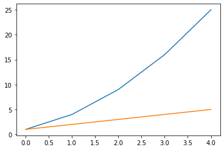

```python
squares = [1,4,9,16,25]
numbers = [1,2,3,4,5]
# subplots function generates one or more plots in the same figure.
# fig represents the entire figure or the collection of plots, and ax represents a single plot in the figure
fig, ax = plt.subplots()
ax.plot(squares)
ax.plot(numbers) # Plots a second line in the figure
plt.show()
```

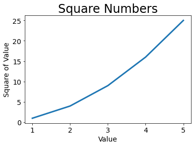

```python
# Adjusting features of the plot, and providing input and output values
input_values = [1,2,3,4,5]
squares = [1,4,9,16,25]

fig, ax = plt.subplots()
ax.plot(input_values, squares, linewidth  = 3)

# Chart title and label axes
ax.set_title('Square Numbers', fontsize = 24)
ax.set_ylabel('Square of Value', fontsize = 14)
ax.set_xlabel('Value', fontsize = 14)

# Size of the tick labels
ax.tick_params(axis = 'both', labelsize = 14)

plt.show()
```

##### Using built-in styles

```python
plt.style.available
```

```
['Solarize_Light2',
 '_classic_test_patch',
 'bmh',
 'classic',
 'dark_background',
 'fast',
 'fivethirtyeight',
 'ggplot',
 'grayscale',
 'seaborn',
 'seaborn-bright',
 'seaborn-colorblind',
 'seaborn-dark',
 'seaborn-dark-palette',
 'seaborn-darkgrid',
 'seaborn-deep',
 'seaborn-muted',
 'seaborn-notebook',
 'seaborn-paper',
 'seaborn-pastel',
 'seaborn-poster',
 'seaborn-talk',
 'seaborn-ticks',
 'seaborn-white',
 'seaborn-whitegrid',
 'tableau-colorblind10']
```

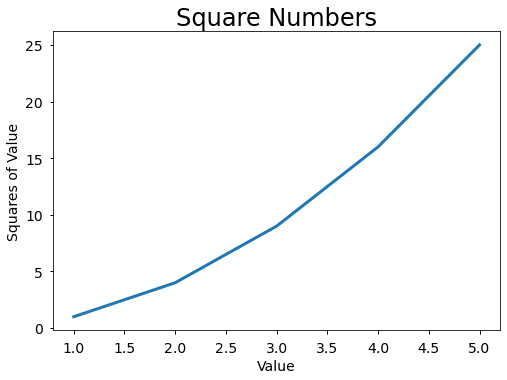

```python
# Using one of the styles

# Importing matplotlib and creating the data
import matplotlib.pyplot as plt
input_values = [1,2,3,4,5]
squares = [1,4,9,16,25]

# Creating the plot
plt.style.use('seaborn-notebook')
fig, ax = plt.subplots()
ax.plot(input_values, squares, linewidth = 3)

# Defining the labels
ax.set_title('Square Numbers', fontsize = 24)
ax.set_xlabel('Value', fontsize = 14)
ax.set_ylabel('Squares of Value', fontsize = 14)

ax.tick_params(axis = 'both', labelsize = 14)
plt.show()
```

##### Plotting and styling individual points using scatter

You might want to plot small values in one color and large values in a different color. It is useful to plot and style individual points based on certain characteristics

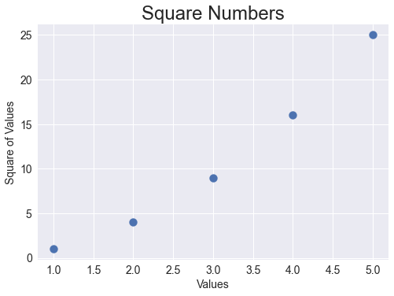

```python
x_values = [1,2,3,4,5]
y_values = [1,4,9,16,25]

plt.style.use('seaborn')
fig, ax = plt.subplots()
ax.scatter(x_values, y_values, s = 100)

# Change the labels size and title
ax.set_title('Square Numbers', fontsize = 24)
ax.set_xlabel('Values', fontsize = 14)
ax.set_ylabel('Square of Values', fontsize = 14)
ax.tick_params(labelsize = 14, axis = 'both', which = 'major')

plt.show()
```

```
(0.0, 1100.0, 0.0, 1100000.0)
```

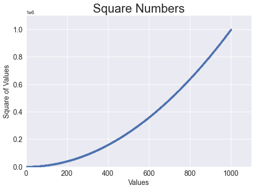

```python
# Creating Data Automatically
x_values = range(1,1001)
y_values = [x**2 for x in x_values]

plt.style.use('seaborn')
fig, ax = plt.subplots()
ax.scatter(x_values, y_values, s = 10)

# Set the labels and title
ax.set_title('Square Numbers', fontsize = 24)
ax.set_xlabel('Values', fontsize = 14)
ax.set_ylabel('Square of Values', fontsize = 14)
ax.tick_params(labelsize = 14, axis = 'both')

# Set the range for each axis
ax.axis([0,1100, 0, 1100 * 1000])
```

## Colormap

Use colormaps to emphasize a pattern in the data

```
(0.0, 1100.0, 0.0, 1100000.0)
```

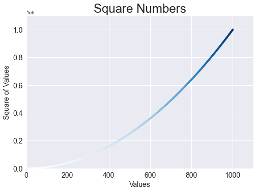

```python
# Making low y_values a light color and high values as darker colors

x_values = range(1,1001)
y_values = [x**2 for x in x_values]

plt.style.use('seaborn')
fig, ax = plt.subplots()
ax.scatter(x_values, y_values, s = 10, c = y_values, cmap = plt.cm.Blues)

# Set the labels and title
ax.set_title('Square Numbers', fontsize = 24)
ax.set_xlabel('Values', fontsize = 14)
ax.set_ylabel('Square of Values', fontsize = 14)
ax.tick_params(labelsize = 14, axis = 'both')

# Set the range for each axis
ax.axis([0,1100, 0, 1100 * 1000])
```

### Random Walks

A random walk is a path that has no clear direction but is determined by a series of random decisions. Imagine it as the path a confused ant would take if it took every step in a random direction.

```python
# use the choice function from the random module to decide which move to make each time a step is taken.
from random import choice
```

```python
class RandomWalk:
    """ A class to generate random walks """
    def __init__(self, num_points = 5000):
        """ Initialize attributes of a walk """
        self.num_points = num_points

        # All walks start at (0,0)
        self.x_values = [0]
        self.y_values = [0]

    def fill_walk(self):
        """ Calculate all the points in a random walk """
        while len(self.x_values) < self.num_points:

            # Decide which direction to go and how far to go in that direction
            x_direction = choice([1,-1]) # Choose to go left or right
            x_distance = choice([0,1,2,3,4]) # How far to move in that direction
            x_step = x_direction * x_distance

            y_direction = choice([1,-1])
            y_distance = choice([0,1,2,3,4])
            y_step = y_direction * y_distance

            # Reject the moves that go nowhere
            if x_step == 0  and y_step == 0:
                continue

            x = self.x_values[-1] + x_step
            y = self.y_values[-1] + y_step

            self.x_values.append(x)
            self.y_values.append(y)
```

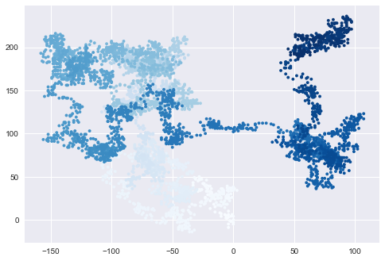

```
Make another random walk? (y/n)? n
```

```python
import matplotlib.pyplot as plt
while True:
    # Make a random walk
    rw = RandomWalk()
    rw.fill_walk()

    # Plot a random walk
    plt.style.use('seaborn')
    fig, ax = plt.subplots()
    point_numbers = range(rw.num_points)
    ax.scatter(rw.x_values, rw.y_values, s = 15, c = point_numbers, cmap = plt.cm.Blues, edgecolors = 'none')
    plt.show()

    keep_running = input('Make another random walk? (y/n)? ')
    if keep_running == 'n':
        break
```

##### Plotting the starting and ending points

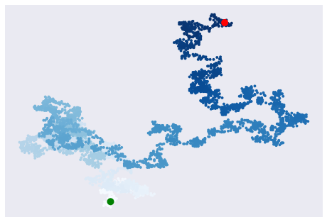

```
Make another random walk? (y/n)? n
```

```python
import matplotlib.pyplot as plt
while True:
    # Make a random walk
    rw = RandomWalk()
    rw.fill_walk()

    # Plot a random walk
    plt.style.use('seaborn')
    fig, ax = plt.subplots()
    point_numbers = range(rw.num_points)
    ax.scatter(rw.x_values, rw.y_values, s = 15, c = point_numbers, cmap = plt.cm.Blues, edgecolors = 'none')
    ax.scatter(0,0, c = 'green', edgecolors = 'none', s = 100)
    ax.scatter(rw.x_values[-1], rw.y_values[-1], s = 100, edgecolors = 'none', c = 'red')

    # Remove the axes
    ax.get_xaxis().set_visible(False)
    ax.get_yaxis().set_visible(False)

    plt.show()

    keep_running = input('Make another random walk? (y/n)? ')
    if keep_running == 'n':
        break
```

### Try it Yourself

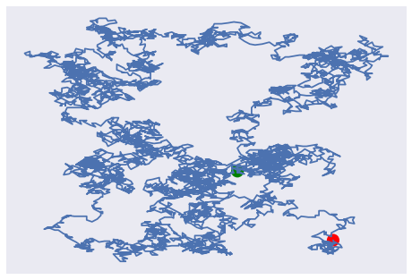

```
Make another random walk? (y/n)? n
```

```python
# Molecular Motion
while True:
    # Make a random walk
    rw = RandomWalk()
    rw.fill_walk()

    # Plot a random walk
    plt.style.use('seaborn')
    fig, ax = plt.subplots()

    ax.plot(rw.x_values, rw.y_values)
    ax.scatter(0,0, c = 'green', edgecolors = 'none', s = 200)
    ax.scatter(rw.x_values[-1], rw.y_values[-1], c = 'red', edgecolors = 'none', s = 200)

    # Remove the axes
    ax.get_xaxis().set_visible(False)
    ax.get_yaxis().set_visible(False)

    plt.show()

    keep_running = input('Make another random walk? (y/n)? ')
    if keep_running == 'n':
        break
```

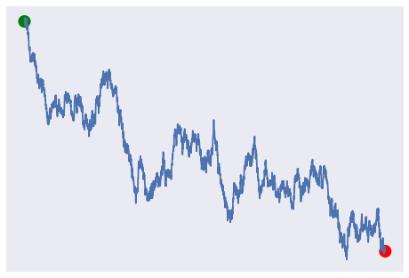

```
Make another random walk? (y/n)? n
```

```python
class RandomWalk:
    """ A class to generate random walks """
    def __init__(self, num_points = 5000):
        """ Initialize attributes of a walk """
        self.num_points = num_points

        # All walks start at (0,0)
        self.x_values = [0]
        self.y_values = [0]

    def fill_walk(self):
        """ Calculate all the points in a random walk """
        while len(self.x_values) < self.num_points:

            # Decide which direction to go and how far to go in that direction
            x_direction = choice([1]) # Choose to go left or right
            x_distance = choice([0,1,2,3,4,5,6,7,8]) # How far to move in that direction
            x_step = x_direction * x_distance

            y_direction = choice([1,-1])
            y_distance = choice([0,1,2,3,4])
            y_step = y_direction * y_distance

            # Reject the moves that go nowhere
            if x_step == 0  and y_step == 0:
                continue

            x = self.x_values[-1] + x_step
            y = self.y_values[-1] + y_step

            self.x_values.append(x)
            self.y_values.append(y)

# Molecular Motion
while True:
    # Make a random walk
    rw = RandomWalk()
    rw.fill_walk()

    # Plot a random walk
    plt.style.use('seaborn')
    fig, ax = plt.subplots()

    ax.plot(rw.x_values, rw.y_values)
    ax.scatter(0,0, c = 'green', edgecolors = 'none', s = 200)
    ax.scatter(rw.x_values[-1], rw.y_values[-1], c = 'red', edgecolors = 'none', s = 200)

    # Remove the axes
    ax.get_xaxis().set_visible(False)
    ax.get_yaxis().set_visible(False)

    plt.show()

    keep_running = input('Make another random walk? (y/n)? ')
    if keep_running == 'n':
        break
```

#### Rolling Dice with Plotly

Creating Interactive visualizations

```python
from random import randint
```

```python
class Die:
    """ A class representing a single die """

    def __init__(self, num_sides = 6):
        self.num_sides = num_sides

    def roll(self):
        """ Return a random value between 1 and the number of sides """
        return randint(1, self.num_sides)
```

```python
# Let's determine exaclty how many times each number appears

die = Die()
results = []
frequencies = []

# Roll the dice 100 times and store the rolls in results
for i in range(0,1000):
    results.append(die.roll())

for value in range(1, die.num_sides + 1):
    frequencies.append(results.count(value))
print('\n')
print(frequencies)
```

```
[154, 166, 186, 172, 170, 152]
```

```python
from plotly.graph_objs import Bar, Layout
from plotly import offline

x_values = list(range(1, die.num_sides + 1))
data = [Bar(x = x_values, y = frequencies)]

x_axis_config = {'title': "Result"}
y_axis_config = {'title': 'Frequency of Result'}
my_layout = Layout(title = 'Results of rolling one D6 1000 times',
                  xaxis = x_axis_config, yaxis = y_axis_config)
offline.plot({'data':data, 'layout':my_layout}, filename = 'd6.html')
```

```
'd6.html'
```

#### Rolling two dice

```python
class Die:
    """ A class representing a single die """

    def __init__(self, num_sides = 6):
        self.num_sides = num_sides

    def roll(self):
        """ Return a random value between 1 and the number of sides """
        return randint(1, self.num_sides)

die1 = Die() # 6 sided dice
die2 = Die() # 6 sided dice

results = []
for i in range(1000):
    results.append(die1.roll() + die2.roll())
```

```python
frequencies = []
max_result = die1.num_sides + die2.num_sides
for value in range(2,  max_result + 1):
    frequencies.append(results.count(value))
print(frequencies)
```

```
[28, 52, 82, 132, 121, 155, 142, 117, 95, 47, 29]
```

```python
from plotly.graph_objs import Bar, Layout
from plotly import offline

x_values = list(range(2, max_result + 1))
data = [Bar(x = x_values, y = frequencies)]

x_axis_config = {'title': "Result", 'dtick':1}
y_axis_config = {'title': 'Frequency of Result'}
my_layout = Layout(title = 'Results of rolling two D6 1000 times',
                  xaxis = x_axis_config, yaxis = y_axis_config)
offline.plot({'data':data, 'layout':my_layout}, filename = 'd6_d6.html')
```

```
'd6_d6.html'
```

### Downloading Data

```python
import csv
```

```python
filename = 'sitka_weather_07-2018_simple.csv'
with open(filename) as f:
    reader = csv.reader(f)
    header_row = next(reader)
    print(header_row)
```

```
['STATION', 'NAME', 'DATE', 'PRCP', 'TAVG', 'TMAX', 'TMIN']
```

```python
for index, column_header in enumerate(header_row):
    print(index, column_header)

# Only need to extract values from columns 2 and 5
```

```
0 STATION
1 NAME
2 DATE
3 PRCP
4 TAVG
5 TMAX
6 TMIN
```

```python
filename = 'sitka_weather_07-2018_simple.csv'
with open(filename) as f:
    reader = csv.reader(f)
    header_row = next(reader)
    print(header_row)

    # Get the high temperature from the file
    highs = []
    for row in reader:
        high = int(row[5])
        highs.append(high)


print(highs)
```

```
['STATION', 'NAME', 'DATE', 'PRCP', 'TAVG', 'TMAX', 'TMIN']
[62, 58, 70, 70, 67, 59, 58, 62, 66, 59, 56, 63, 65, 58, 56, 59, 64, 60, 60, 61, 65, 65, 63, 59, 64, 65, 68, 66, 64, 67, 65]
```

```python
# Plotting data in a temperature chart
import matplotlib.pyplot as plt
```

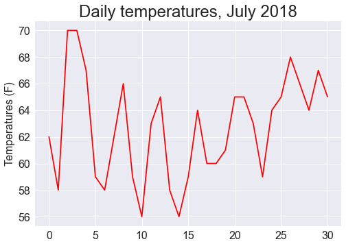

```python
plt.style.use('seaborn')
fig, ax = plt.subplots()
ax.plot(highs, c = 'red')

# Format the plot
ax.set_title('Daily temperatures, July 2018', fontsize = 24)
ax.set_xlabel('', fontsize = 16)
ax.set_ylabel('Temperatures (F)', fontsize = 16)
ax.tick_params(axis = 'both', which = 'major', labelsize = 16)

plt.show()
```

```python
# strptime example
from datetime import datetime
first_date = datetime.strptime('2018-07-01', '%Y-%m-%d')
print(first_date)
```

```
2018-07-01 00:00:00
```

```python
filename = 'sitka_weather_07-2018_simple.csv'
with open(filename) as f:
    reader = csv.reader(f)
    header = next(reader)
    print(header)

    dates, highs = [], []
    for row in reader:
        current_date = datetime.strptime(row[2], '%Y-%m-%d')
        high = int(row[5])
        dates.append(current_date)
        highs.append(high)
```

```
['STATION', 'NAME', 'DATE', 'PRCP', 'TAVG', 'TMAX', 'TMIN']
```

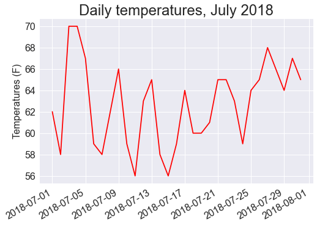

```python
plt.style.use('seaborn')
fig, ax = plt.subplots()
ax.plot(dates, highs, c = 'red')

# Format the plot
ax.set_title('Daily temperatures, July 2018', fontsize = 24)
ax.set_xlabel('', fontsize = 16)
fig.autofmt_xdate()
ax.set_ylabel('Temperatures (F)', fontsize = 16)
ax.tick_params(axis = 'both', which = 'major', labelsize = 16)

plt.show()
```

```python
filename = 'sitka_weather_2018_simple.csv'
with open(filename) as f:
    reader = csv.reader(f)
    header = next(reader)
    print(header)

    dates, highs, lows = [],[], []
    for row in reader:
        current_date = datetime.strptime(row[2], '%Y-%m-%d')
        high = int(row[5])
        low = int(row[-1])

        dates.append(current_date)
        highs.append(high)
        lows.append(low)
```

```
['STATION', 'NAME', 'DATE', 'PRCP', 'TAVG', 'TMAX', 'TMIN']
```

[figure not shown]

```python
plt.style.use('seaborn')
fig, ax = plt.subplots()
ax.plot(dates, highs, c = 'red')
ax.plot(dates, lows, c = 'blue')

# Format the plot
ax.set_title('Daily Temperatures, July 2018', fontsize = 24)
ax.set_xlabel('', fontsize = 16)
fig.autofmt_xdate()
ax.set_ylabel('Temperatures (F)', fontsize = 16)
ax.tick_params(axis = 'both', which = 'major', labelsize = 16)

plt.show()
```

##### Shading an Area in the Chart

[figure not shown]

```python
plt.style.use('seaborn')
fig, ax = plt.subplots()
ax.plot(dates, highs, c = 'red', alpha = 0.5)
ax.plot(dates, lows, c = 'blue', alpha = 0.5)
ax.fill_between(dates, highs, lows, facecolor = 'blue', alpha = 0.1)

# Format the plot
ax.set_title('Daily Temperatures, July 2018', fontsize = 24)
ax.set_xlabel('', fontsize = 16)
fig.autofmt_xdate()
ax.set_ylabel('Temperatures (F)', fontsize = 16)
ax.tick_params(axis = 'both', which = 'major', labelsize = 16)

plt.show()
```

##### Error Checking

```python
# Let's check the headers of the death valley dataset
filename = 'death_valley_2018_simple.csv'
with open(filename) as f:
    reader = csv.reader(f)
    header = next(reader)
    print(header)

# Indexes of TMAX and TMIN are 4 and 5 respectively.
    dates, highs, lows = [],[],[]
    for row in reader:

        current_date = datetime.strptime(row[2], '%Y-%m-%d')

        try:
            high = int(row[4])
            low = int(row[5])

        except ValueError:
            print('Missing data for {}'.format(current_date))

        else:
            dates.append(current_date)
            highs.append(high)
            lows.append(low)
```

```
['STATION', 'NAME', 'DATE', 'PRCP', 'TMAX', 'TMIN', 'TOBS']
Missing data for 2018-02-18 00:00:00
```

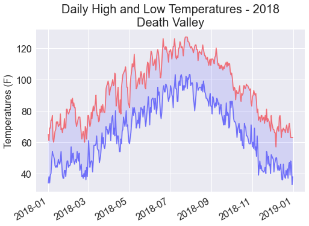

```python
plt.style.use('seaborn')
fig, ax = plt.subplots()
ax.plot(dates, highs, c = 'red', alpha = 0.5)
ax.plot(dates, lows, c = 'blue', alpha = 0.5)
ax.fill_between(dates, highs, lows, facecolor = 'blue', alpha = 0.1)

# Format the plot
ax.set_title('Daily High and Low Temperatures - 2018\nDeath Valley', fontsize = 20)
ax.set_xlabel('', fontsize = 16)
fig.autofmt_xdate()
ax.set_ylabel('Temperatures (F)', fontsize = 16)
ax.tick_params(axis = 'both', which = 'major', labelsize = 16)

plt.show()
```

### Try it yourself

```
['STATION', 'NAME', 'DATE', 'PRCP', 'TAVG', 'TMAX', 'TMIN']
```

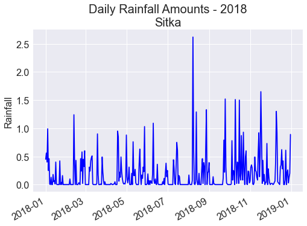

```python
# Sitka Rainfall
filename = 'sitka_weather_2018_simple.csv'
with open(filename) as f:
    reader = csv.reader(f)
    header = next(reader)
    print(header)

    dates, rain = [],[]
    for row in reader:
        current_date = datetime.strptime(row[2], '%Y-%m-%d')
        rain_in_inches = float(row[3])

        dates.append(current_date)
        rain.append(rain_in_inches)

plt.style.use('seaborn')
fig, ax = plt.subplots()
ax.plot(dates, rain, c = 'blue')

# Format the plot
ax.set_title('Daily Rainfall Amounts - 2018\nSitka', fontsize = 20)
ax.set_xlabel('', fontsize = 16)
fig.autofmt_xdate()
ax.set_ylabel('Rainfall', fontsize = 16)
ax.tick_params(axis = 'both', which = 'major', labelsize = 16)

plt.show()
```

[figure not shown]

```python
# --------------------------------  Sitka-Death Valley Comparisions on the same scale--------------------------------

#----------------- Sitka --------------------
filename = 'sitka_weather_2018_simple.csv'
with open(filename) as f:
    reader = csv.reader(f)
    header = next(reader)
    #print(header)

    dates, highs, lows = [],[], []
    for row in reader:
        current_date = datetime.strptime(row[2], '%Y-%m-%d')
        high = int(row[5])
        low = int(row[-1])

        dates.append(current_date)
        highs.append(high)
        lows.append(low)

# Plot data.
fig = plt.figure(dpi=128, figsize=(10, 6))
plt.plot(dates, highs, c='red', alpha=0.5)
plt.plot(dates, lows, c='blue', alpha=0.5)
plt.fill_between(dates, highs, lows, facecolor='blue', alpha=0.1)

# Format plot.
title = "Daily high and low temperatures - 2014\nSitka, AK"
plt.title(title, fontsize=20)
plt.xlabel('', fontsize=16)
fig.autofmt_xdate()
plt.ylabel("Temperature (F)", fontsize=16)
plt.tick_params(axis='both', which='major', labelsize=16)
plt.ylim(10, 120)

plt.show()
```

```
Missing data for 2018-02-18 00:00:00
```

[figure not shown]

```python
#----------------- Death valley --------------------

filename = 'death_valley_2018_simple.csv'
with open(filename) as f:
    reader = csv.reader(f)
    header = next(reader)
    #print(header)

# Indexes of TMAX and TMIN are 4 and 5 respectively.
    dates, highs, lows = [],[],[]
    for row in reader:

        current_date = datetime.strptime(row[2], '%Y-%m-%d')

        try:
            high = int(row[4])
            low = int(row[5])

        except ValueError:
            print('Missing data for {}'.format(current_date))

        else:
            dates.append(current_date)
            highs.append(high)
            lows.append(low)


# Plot data.
fig = plt.figure(dpi=128, figsize=(10, 6))
plt.plot(dates, highs, c='red', alpha=0.5)
plt.plot(dates, lows, c='blue', alpha=0.5)
plt.fill_between(dates, highs, lows, facecolor='blue', alpha=0.1)

# Format plot.
title = "Daily high and low temperatures - 2014\nSitka, AK"
plt.title(title, fontsize=20)
plt.xlabel('', fontsize=16)
fig.autofmt_xdate()
plt.ylabel("Temperature (F)", fontsize=16)
plt.tick_params(axis='both', which='major', labelsize=16)

plt.show()
```

### Mapping global datasets - json

##### Downloading the Earthquake data

```python
import json
from plotly.graph_objs import Scattergeo, Layout
from plotly import offline
```

```python
filename = 'eq_data_1_day_m1.json'
with open(filename) as f:
    all_eq_data = json.load(f) # Will convert the data into a format that python can work with.

# Writing the same data into a more readable format.
readable_file = 'readable_eq_data.json'
with open(readable_file, 'w') as f:
    json.dump(all_eq_data, f, indent = 4)
```

##### Making a list of all earthquakes

```python
filename = 'eq_data_1_day_m1.json'
with open(filename) as f:
    all_eq_data = json.load(f)

all_eq_dicts = all_eq_data['features'] # 158 earthquakes

mags, lons, lats = [],[],[]

for eq_dict in all_eq_dicts:
    mag = eq_dict['properties']['mag']
    lon = eq_dict['geometry']['coordinates'][0]
    lat = eq_dict['geometry']['coordinates'][1]

    mags.append(mag)
    lons.append(lon)
    lats.append(lat)


print(mags[:10])
print(lons[:5])
print(lats[:5])

# Map the earthquakes
data = [Scattergeo(lon = lons, lat = lats)]
my_layout = Layout(title = 'Global Earthquakes')

fig = {'data': data, 'layout': my_layout}
offline.plot(fig, filename = 'global_earthquakes.html')
```

```
[0.96, 1.2, 4.3, 3.6, 2.1, 4, 1.06, 2.3, 4.9, 1.8]
[-116.7941667, -148.9865, -74.2343, -161.6801, -118.5316667]
[33.4863333, 64.6673, -12.1025, 54.2232, 35.3098333]
```

```
'global_earthquakes.html'
```

##### A Different Way of Specifying Chart Data

```python
# Customizing marker size, colors, and adding hover text.
# Communicating the severity of each earthquake so that it is informative.

filename = 'eq_data_1_day_m1.json'
with open(filename) as f:
    all_eq_data = json.load(f)

map_title = all_eq_data['metadata']['title']
all_eq_dicts = all_eq_data['features'] # 158 earthquakes

mags, lons, lats, hover_texts = [],[],[],[]

for eq_dict in all_eq_dicts:
    mag = eq_dict['properties']['mag']
    lon = eq_dict['geometry']['coordinates'][0]
    lat = eq_dict['geometry']['coordinates'][1]
    title = eq_dict['properties']['title']

    mags.append(mag)
    lons.append(lon)
    lats.append(lat)
    hover_texts.append(title)


print(mags[:10])
print(lons[:5])
print(lats[:5])

# Map the earthquakes
data = [{
    'type': 'scattergeo',
    'lon': lons,
    'lat': lats,
    'text': hover_texts,
    'marker': {
        'size':[5*mag for mag in mags],
        'color': mags,
        'colorscale': 'Viridis',
        'reversescale': True,
        'colorbar': {'title': 'Magnitude'}
    },
}]
# This allows us to specify customizations more easily that the previous format as
# the previous chunk is not the best way to customize the presentation

my_layout = Layout(title = map_title)

fig = {'data': data, 'layout': my_layout}
offline.plot(fig, filename = 'global_earthquakes.html')
```

```
[0.96, 1.2, 4.3, 3.6, 2.1, 4, 1.06, 2.3, 4.9, 1.8]
[-116.7941667, -148.9865, -74.2343, -161.6801, -118.5316667]
[33.4863333, 64.6673, -12.1025, 54.2232, 35.3098333]
```

```
'global_earthquakes.html'
```